# QK Box 10.5

We show several ways to approach this data set, ranging from the “traditional” OLS nested analysis to simplified analysis using means, to linear mixed models and REML/ML. At this stage, it’s useful to show you the ways you might encounter these analyses, but in practice you’d use one.

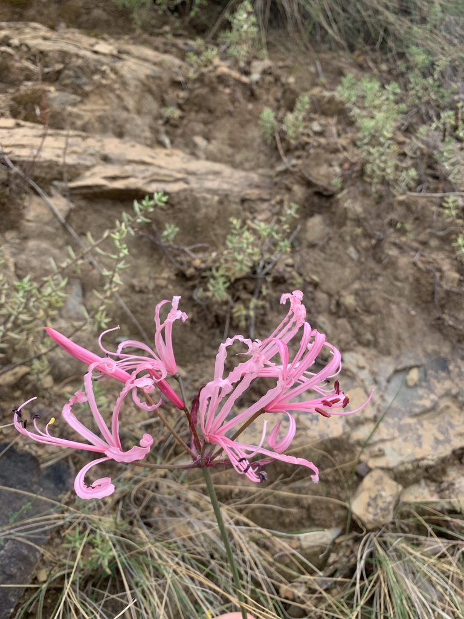

*Nerine humilis*. Sam McCarren , via iNaturalist. There’s also a good picture of the different phenotypes as Figure 1 of Newman et al.

The paper is [here](https://doi.org/10.1111/evo.12736), and the data are at [dryad](https://datadryad.org/stash/dataset/doi:10.5061/dryad.c8fb1), as an Excel file *floral_traits nested ANOVA* and we’ve used the *tepal length* sheet for this example*.*

Newman, E., Manning, J. & Anderson, B. (2015). Local adaptation: Mechanical fit between floral ecotypes of *Nerine humilis* (Amaryllidaceae) and pollinator communities. *Evolution*, 69, 2262-75.

### Preliminaries

First, load the required packages (afex, car, lattice, lme4, lmerTest, nlme, VCA, Rmisc)

Import newman data file (newman_tepal.csv)

```r
newman_tepal <- read.csv("../data/newman_tepal.csv")
head(newman_tepal,10)
```

|  | population | phenotype | tepal | population1 |
| --- | --- | --- | --- | --- |
| 1 | 1 | Short | 26.08 | a |
| 2 | 1 | Short | 20.04 | a |
| 3 | 1 | Short | 18.70 | a |
| 4 | 1 | Short | 21.04 | a |
| 5 | 1 | Short | 16.42 | a |
| 6 | 1 | Short | 18.26 | a |
| 7 | 1 | Short | 23.92 | a |
| 8 | 1 | Short | 17.81 | a |
| 9 | 1 | Short | 24.83 | a |
| 10 | 1 | Short | 22.44 | a |

Make population a factor

```r
newman_tepal$population <- factor(newman_tepal$population)
```

Calculate summary stats by groups

```r
newman_sum <- summarySE(newman_tepal,measurevar='tepal', groupvars= c('population','phenotype'))
newman_sum
```

| population | phenotype | N | tepal | sd | se | ci |
| --- | --- | --- | --- | --- | --- | --- |
| 1 | Short | 20 | 20.80 | 2.582 | 0.5773 | 1.208 |
| 2 | Short | 21 | 18.87 | 4.582 | 1.0000 | 2.086 |
| 3 | Short | 27 | 20.65 | 3.915 | 0.7533 | 1.549 |
| 4 | Short | 20 | 21.61 | 3.571 | 0.7985 | 1.671 |
| 5 | Short | 23 | 21.46 | 4.398 | 0.9170 | 1.902 |
| 6 | Short | 19 | 29.42 | 4.498 | 1.0318 | 2.168 |
| 7 | Short | 43 | 24.94 | 4.466 | 0.6810 | 1.374 |
| 9 | Long | 22 | 29.92 | 5.720 | 1.2194 | 2.536 |
| 10 | Long | 26 | 29.50 | 4.420 | 0.8669 | 1.785 |
| 11 | Long | 25 | 29.08 | 3.947 | 0.7893 | 1.629 |

do preliminary checks (look OK)

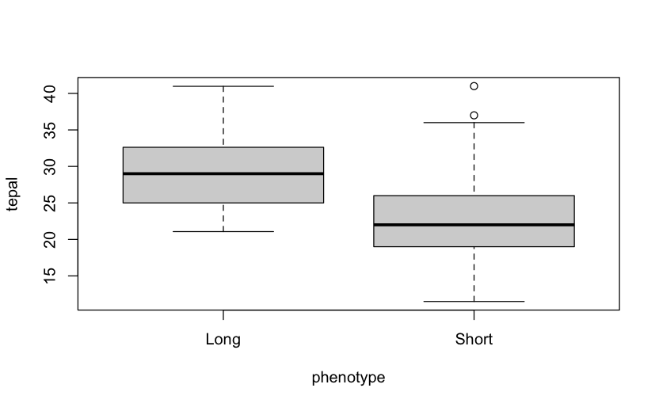

```r
boxplot(tepal~phenotype, data=newman_tepal)
```

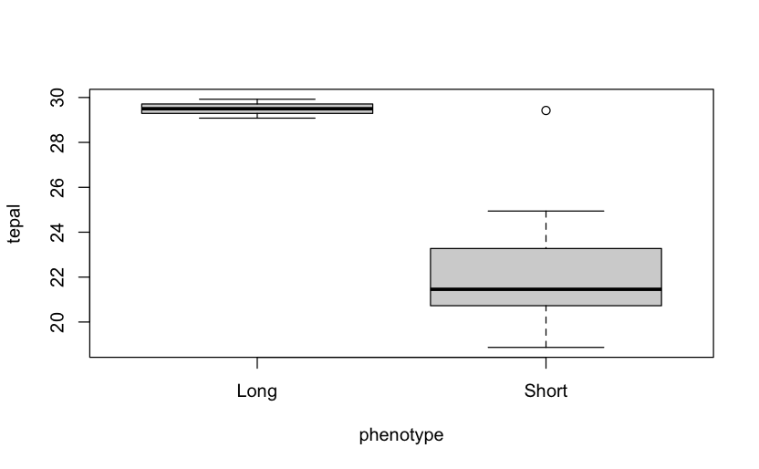

```r
boxplot(tepal~phenotype, data=newman_sum)
```

## Fit nested anova model

Note: Defaults to Type I SS in *R* - can’t change it with nested aov structures. Need to get Type III from another package (e.g. spss) - very similar to Type I and II anyway

```r
newman.aov <- aov(tepal~phenotype+Error(population), newman_tepal)
```

Plot residuals based on colonies

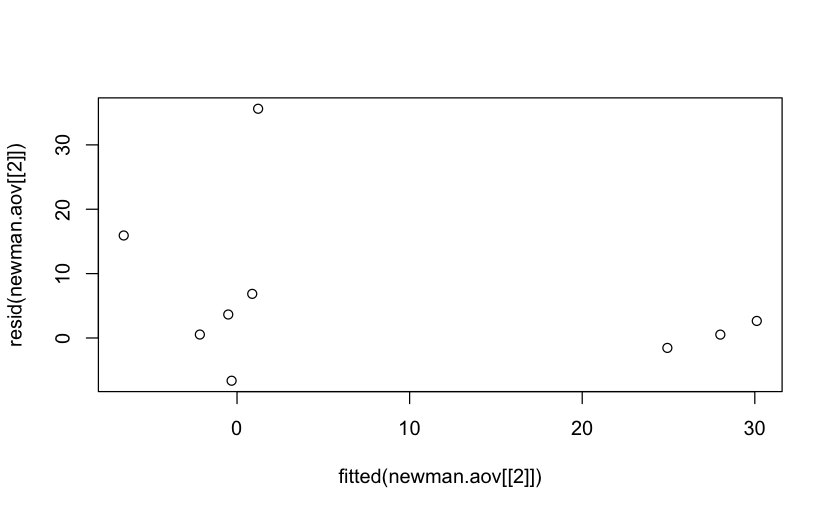

```r
plot(resid(newman.aov[[2]])~fitted(newman.aov[[2]]))
```

### Get anova summary

```r
options(digits=3)
summary(newman.aov)
```

```
Error: population
          Df Sum Sq Mean Sq F value Pr(>F)
phenotype  1   2363    2363    11.6 0.0094 **
Residuals  8   1636     205
---
Signif. codes:  0 ‘***’ 0.001 ‘**’ 0.01 ‘*’ 0.05 ‘.’ 0.1 ‘ ’ 1

Error: Within
           Df Sum Sq Mean Sq F value Pr(>F)
Residuals 236   4364    18.5
```

### Use lm command as an alternative

```r
newman.lm1 <- lm(tepal~phenotype+phenotype/population, newman_tepal)
summary(newman.lm1)
```

```
Call:
lm(formula = tepal ~ phenotype + phenotype/population, data = newman_tepal)

Residuals:
   Min     1Q Median     3Q    Max
-8.852 -2.965 -0.222  2.864 11.579

Coefficients: (10 not defined because of singularities)
                           Estimate Std. Error t value Pr(>|t|)
(Intercept)                27.22093    0.53414   50.96  < 2e-16 ***
phenotype1                  2.27907    0.53414    4.27  2.9e-05 ***
phenotypeLong:population1  -0.00227    2.10354    0.00  0.99914
phenotypeShort:population1 -4.13836    1.16386   -3.56  0.00046 ***
phenotypeLong:population2        NA         NA      NA       NA
phenotypeShort:population2 -6.07281    1.14479   -5.30  2.6e-07 ***
phenotypeLong:population3        NA         NA      NA       NA
phenotypeShort:population3 -4.29371    1.05587   -4.07  6.5e-05 ***
phenotypeLong:population4        NA         NA      NA       NA
phenotypeShort:population4 -3.33686    1.16386   -2.87  0.00452 **
phenotypeLong:population5        NA         NA      NA       NA
phenotypeShort:population5 -3.48534    1.11084   -3.14  0.00192 **
phenotypeLong:population6        NA         NA      NA       NA
phenotypeShort:population6  4.47919    1.18458    3.78  0.00020 ***
phenotypeLong:population7        NA         NA      NA       NA
phenotypeShort:population7       NA         NA      NA       NA
phenotypeLong:population8   0.42227    1.24567    0.34  0.73492
phenotypeShort:population8       NA         NA      NA       NA
phenotypeLong:population9        NA         NA      NA       NA
phenotypeShort:population9       NA         NA      NA       NA
---
Signif. codes:  0 ‘***’ 0.001 ‘**’ 0.01 ‘*’ 0.05 ‘.’ 0.1 ‘ ’ 1

Residual standard error: 4.3 on 236 degrees of freedom
Multiple R-squared:  0.478, Adjusted R-squared:  0.458
F-statistic:   24 on 9 and 236 DF,  p-value: <2e-16
```

```r
anova(newman.lm1)
```

```
Analysis of Variance Table

Response: tepal
                      Df Sum Sq Mean Sq F value Pr(>F)
phenotype              1   2363    2363   127.8 <2e-16 ***
phenotype:population   8   1636     205    11.1  3e-13 ***
Residuals            236   4364      18
---
Signif. codes:  0 ‘***’ 0.001 ‘**’ 0.01 ‘*’ 0.05 ‘.’ 0.1 ‘ ’ 1
```

```r
Anova(newman.lm1, type="II")
```

```
Note: model has aliased coefficients
      sums of squares computed by model comparison
```

```
Anova Table (Type II tests)

Response: tepal
                     Sum Sq  Df F value Pr(>F)
phenotype              2363   1   127.8 <2e-16 ***
phenotype:population   1636   8    11.1  3e-13 ***
Residuals              4364 236
---
Signif. codes:  0 ‘***’ 0.001 ‘**’ 0.01 ‘*’ 0.05 ‘.’ 0.1 ‘ ’ 1
```

```r
1-pf(11.060, 8, 236, lower.tail = TRUE, log.p = FALSE)
```

```
[1] 3.02e-13
```

This output is treating populations as a fixed effect, so to show comparability with the initial nested effect, we need to recalculate the test for phenotype, using populations as the denominator.

```r
f <- 127.8/11.1
f
```

```
[1] 11.5
```

```r
1-pf(f, 1, 8, lower.tail = TRUE, log.p = FALSE)
```

```
[1] 0.00946
```

## Demonstrate nested is similar to one-way on colony means

```r
newman.aov2 <- aov(tepal~phenotype, newman_sum)
summary(newman.aov2)
```

```
            Df Sum Sq Mean Sq F value Pr(>F)
phenotype    1  101.9   101.9    10.8  0.011 *
Residuals    8   75.6     9.4
---
Signif. codes:  0 ‘***’ 0.001 ‘**’ 0.01 ‘*’ 0.05 ‘.’ 0.1 ‘ ’ 1
```

Analysis using means won’t be exactly the same because sample sizes vary among populations.

### Variance components using VCA package

```r
newman.vca <- anovaMM(tepal~phenotype/(population), newman_tepal)
```

```
Convert variable phenotype from "character" to "factor"!
```

```r
newman.vca
```

```
ANOVA-Type Estimation of Mixed Model:
--------------------------------------

    [Fixed Effects]

           int  phenotypeLong phenotypeShort
         22.54           6.96           0.00


    [Variance Components]

  Name                 DF        SS          MS         VC        %Total    SD       CV[%]
1 total                67.087549                        26.148709 100       5.113581 20.692506
2 phenotype:population 8         1636.057375 204.507172 7.657816  29.285635 2.767276 11.197999
3 error                236       4363.850882 18.490894  18.490894 70.714365 4.300104 17.400708

Mean: 24.7 (N = 246)

Experimental Design: unbalanced  |  Method: ANOVA
```

```r
VCAinference(newman.vca, alpha=0.05, VarVC=TRUE, ci.method="satterthwaite")
```

```
Inference from Mixed Model Fit
------------------------------

> VCA Result:
-------------

    [Fixed Effects]

           int  phenotypeLong phenotypeShort
         22.54           6.96           0.00


    [Variance Components]

  Name                 DF      SS        MS       VC      %Total  SD     CV[%]   Var(VC)
1 total                67.0875                    26.1487 100     5.1136 20.6925
2 phenotype:population 8       1636.0574 204.5072 7.6578  29.2856 2.7673 11.198  18.5087
3 error                236     4363.8509 18.4909  18.4909 70.7144 4.3001 17.4007 2.8976

Mean: 24.7 (N = 246)

Experimental Design: unbalanced  |  Method: ANOVA


> VC:
-----
                     Estimate     DF CI LCL CI UCL One-Sided LCL One-Sided UCL
total                   26.15  67.09  19.15   37.9         20.12          35.6
phenotype:population     7.66   6.62   3.29   33.5          3.75          25.9
error                   18.49 236.00  15.56   22.3         15.99          21.7

> SD:
-----
                     Estimate     DF CI LCL CI UCL One-Sided LCL One-Sided UCL
total                    5.11  67.09   4.38   6.15          4.49          5.97
phenotype:population     2.77   6.62   1.81   5.79          1.94          5.09
error                    4.30 236.00   3.94   4.73          4.00          4.65

> CV[%]:
--------
                     Estimate     DF CI LCL CI UCL One-Sided LCL One-Sided UCL
total                    20.7  67.09  17.71   24.9         18.15          24.2
phenotype:population     11.2   6.62   7.34   23.4          7.84          20.6
error                    17.4 236.00  15.96   19.1         16.18          18.8


95% Confidence Level
Satterthwaite methodology used for computing CIs
```

## Mixed model using lme4

```r
newman.reml <- lmer(tepal~phenotype + (1|population), newman_tepal)
summary(newman.reml)
```

```
Linear mixed model fit by REML. t-tests use Satterthwaite's method ['lmerModLmerTest']
Formula: tepal ~ phenotype + (1 | population)
   Data: newman_tepal

REML criterion at convergence: 1435

Scaled residuals:
    Min      1Q  Median      3Q     Max
-2.0493 -0.6346 -0.0382  0.6484  2.8575

Random effects:
 Groups     Name        Variance Std.Dev.
 population (Intercept)  8.45    2.91
 Residual               18.50    4.30
Number of obs: 246, groups:  population, 10

Fixed effects:
            Estimate Std. Error    df t value Pr(>|t|)
(Intercept)    26.02       1.05  7.80   24.82    1e-08 ***
phenotype1      3.48       1.05  7.80    3.32    0.011 *
---
Signif. codes:  0 ‘***’ 0.001 ‘**’ 0.01 ‘*’ 0.05 ‘.’ 0.1 ‘ ’ 1

Correlation of Fixed Effects:
           (Intr)
phenotype1 0.398
```

```r
newman.ml <- lmer(tepal~phenotype + (1|population), newman_tepal, REML=F)
summary(newman.ml)
```

```
Linear mixed model fit by maximum likelihood . t-tests use Satterthwaite's method ['lmerModLmerTest']
Formula: tepal ~ phenotype + (1 | population)
   Data: newman_tepal

     AIC      BIC   logLik deviance df.resid
    1446     1460     -719     1438      242

Scaled residuals:
    Min      1Q  Median      3Q     Max
-2.0468 -0.6475 -0.0484  0.6600  2.8986

Random effects:
 Groups     Name        Variance Std.Dev.
 population (Intercept)  6.56    2.56
 Residual               18.50    4.30
Number of obs: 246, groups:  population, 10

Fixed effects:
            Estimate Std. Error     df t value Pr(>|t|)
(Intercept)   26.019      0.935  9.692   27.84  1.4e-10 ***
phenotype1     3.480      0.935  9.692    3.72   0.0042 **
---
Signif. codes:  0 ‘***’ 0.001 ‘**’ 0.01 ‘*’ 0.05 ‘.’ 0.1 ‘ ’ 1

Correlation of Fixed Effects:
           (Intr)
phenotype1 0.398
```

CI on variance components (remembering to square CIs from lmer with are in SD units)

```r
newman.ci <- confint.merMod(newman.reml)
```

```
Computing profile confidence intervals ...
```

```r
newman.vc <- (newman.ci)^2
print(newman.vc)
```

```
             2.5 % 97.5 %
.sig01        2.58   19.9
.sigma       15.53   22.3
(Intercept) 575.54  786.6
phenotype1    2.11   30.4
```

Test fixed effect using likelihood ratio tests

```r
newman.lme <- lmer(tepal~phenotype + (1|population), newman_tepal, REML=F)
newman.lme1 <- lmer(tepal~(1|population), newman_tepal, REML=F)
anova(newman.lme,newman.lme1)
```

```
Data: newman_tepal
Models:
newman.lme1: tepal ~ (1 | population)
newman.lme: tepal ~ phenotype + (1 | population)
            npar  AIC  BIC logLik deviance Chisq Df Pr(>Chisq)
newman.lme1    3 1453 1464   -724     1447
newman.lme     4 1446 1460   -719     1438  8.65  1     0.0033 **
---
Signif. codes:  0 ‘***’ 0.001 ‘**’ 0.01 ‘*’ 0.05 ‘.’ 0.1 ‘ ’ 1
```

### Using lmerTest

```r
summary(newman.reml)
```

```
Linear mixed model fit by REML. t-tests use Satterthwaite's method ['lmerModLmerTest']
Formula: tepal ~ phenotype + (1 | population)
   Data: newman_tepal

REML criterion at convergence: 1435

Scaled residuals:
    Min      1Q  Median      3Q     Max
-2.0493 -0.6346 -0.0382  0.6484  2.8575

Random effects:
 Groups     Name        Variance Std.Dev.
 population (Intercept)  8.45    2.91
 Residual               18.50    4.30
Number of obs: 246, groups:  population, 10

Fixed effects:
            Estimate Std. Error    df t value Pr(>|t|)
(Intercept)    26.02       1.05  7.80   24.82    1e-08 ***
phenotype1      3.48       1.05  7.80    3.32    0.011 *
---
Signif. codes:  0 ‘***’ 0.001 ‘**’ 0.01 ‘*’ 0.05 ‘.’ 0.1 ‘ ’ 1

Correlation of Fixed Effects:
           (Intr)
phenotype1 0.398
```

Get more reliable F-test than original anova for fixed effect based on Satterthwaite’s (default) and Kenward-Roger’s adjustment to df

```r
anova(newman.reml)
```

```
Type III Analysis of Variance Table with Satterthwaite's method
          Sum Sq Mean Sq NumDF DenDF F value Pr(>F)
phenotype    204     204     1   7.8      11  0.011 *
---
Signif. codes:  0 ‘***’ 0.001 ‘**’ 0.01 ‘*’ 0.05 ‘.’ 0.1 ‘ ’ 1
```

```r
anova(newman.reml, ddf="Kenward-Roger")
```

```
Type III Analysis of Variance Table with Kenward-Roger's method
          Sum Sq Mean Sq NumDF DenDF F value Pr(>F)
phenotype    204     204     1  7.97      11  0.011 *
---
Signif. codes:  0 ‘***’ 0.001 ‘**’ 0.01 ‘*’ 0.05 ‘.’ 0.1 ‘ ’ 1
```